# SCS 2017: Exploring Regression with Linear Hypotheses

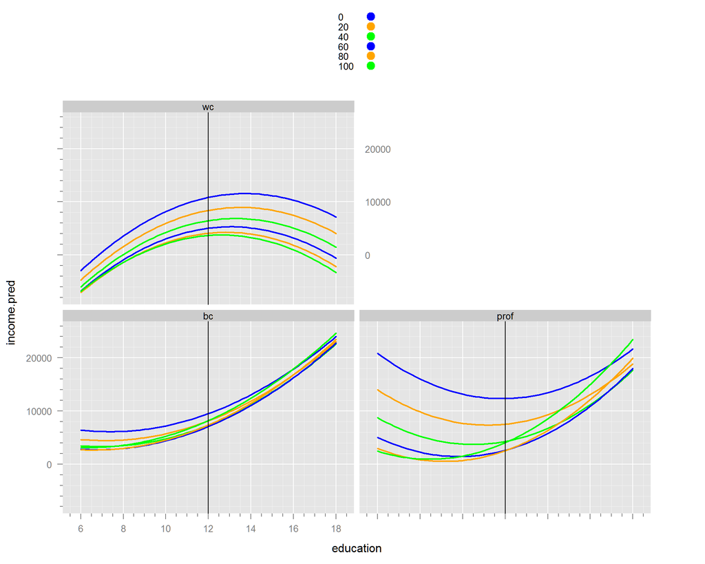

```r
xyplot(income.pred ~ education | type, pred, groups = women, type = 'l',
       auto.key = T) + layer(panel.abline(v = 12))
```

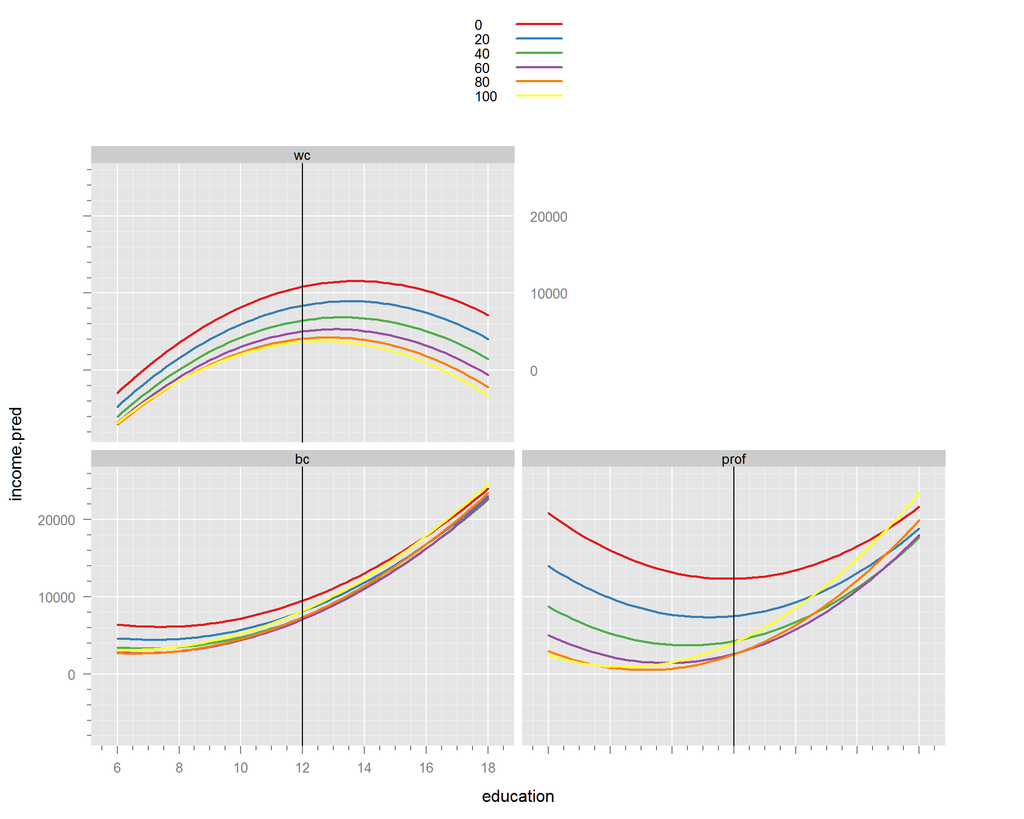

```r
gd(6, lty = 1, lwd = 2)
xyplot(income.pred ~ education | type, pred, groups = women, type = 'l',
       auto.key = list(points = F, lines = T)) +
  layer(panel.abline(v = 12))
```

Estimating the ‘value of education’:

We print a list of expressions that generates a block of the X matrix:

```r
Lfx(fit3q)
```

```
   list( 1,
   1 * M(type),
   1 * education,
   1 * women,
   1 * M(I(education^2)),
   1 * M(I(women^2)),
   1 * education * women,
   1 * M(type) * education,
   1 * M(type) * women,
   1 * M(type) * M(I(education^2)),
   1 * M(type) * M(I(women^2)),
   1 * M(type) * education * women
   )
```

We can use the list of expressions to generate the design matrix over the data frame ‘pred’.

```r
Led <- Lfx(
  fit3q,
  list( 1,
      1 * M(type),
      1 * education,
      1 * women,
      1 * M(I(education^2)),
      1 * M(I(women^2)),
      1 * education * women,
      1 * M(type) * education,
      1 * M(type) * women,
      1 * M(type) * M(I(education^2)),
      1 * M(type) * M(I(women^2)),
      1 * M(type) * education * women ),
  pred)
dim(Led)
```

```
   [1] 1098   18
```

```r
head(Led)
```

```
     (Intercept) typeprof typewc education women I(education^2) I(women^2) education:women
   1           1        0      0         6     0             36          0               0
   2           1        0      0         6    20             36        400             120
   3           1        0      0         6    40             36       1600             240
   4           1        0      0         6    60             36       3600             360
   5           1        0      0         6    80             36       6400             480
   6           1        0      0         6   100             36      10000             600
     typeprof:education typewc:education typeprof:women typewc:women typeprof:I(education^2)
   1                  0                0              0            0                       0
   2                  0                0              0            0                       0
   3                  0                0              0            0                       0
   4                  0                0              0            0                       0
   5                  0                0              0            0                       0
   6                  0                0              0            0                       0
     typewc:I(education^2) typeprof:I(women^2) typewc:I(women^2) typeprof:education:women
   1                     0                   0                 0                        0
   2                     0                   0                 0                        0
   3                     0                   0                 0                        0
   4                     0                   0                 0                        0
   5                     0                   0                 0                        0
   6                     0                   0                 0                        0
     typewc:education:women
   1                      0
   2                      0
   3                      0
   4                      0
   5                      0
   6                      0
```

The list of expressions can be edited easily to differentiate with respect to a continuous variable.

To get the value of education, differentiate each term with respect to education. Leave expression of the form ‘M(…)’ as is because they generate blocks of the right size for factors. Also, products of ‘M’ objects generate the columns of the X matrix for interaction terms.

```r
Led.deriv <- Lfx(fit3q,
           list( 0,
                 0 * M(type),
                 1 ,
                 0 * women,
                 2 * M(I(education)),
                 0 * M(I(women^2)),
                 1 * women,
                 1 * M(type) * 1,
                 0 * M(type) * women,
                 2 * M(type) * M(I(education)),
                 0 * M(type) * M(I(women^2)),
                 1 * M(type) * 1 * women ),
           pred)
ed.deriv <- walddf(fit3q, Led.deriv, data = pred)
head(ed.deriv)
```

```
          coef       se        U2        L2 women education type income.pred
   1 -429.4269 741.6629 1053.8990 -1912.753     0         6   bc    6385.627
   2 -363.8062 673.3931  982.9800 -1710.592    20         6   bc    4638.110
   3 -298.1855 616.1244  934.0634 -1530.434    40         6   bc    3437.509
   4 -232.5647 573.1641  913.7634 -1378.893    60         6   bc    2783.822
   5 -166.9440 547.8883  928.8326 -1262.721    80         6   bc    2677.049
   6 -101.3233 542.7733  984.2233 -1186.870   100         6   bc    3117.192
```

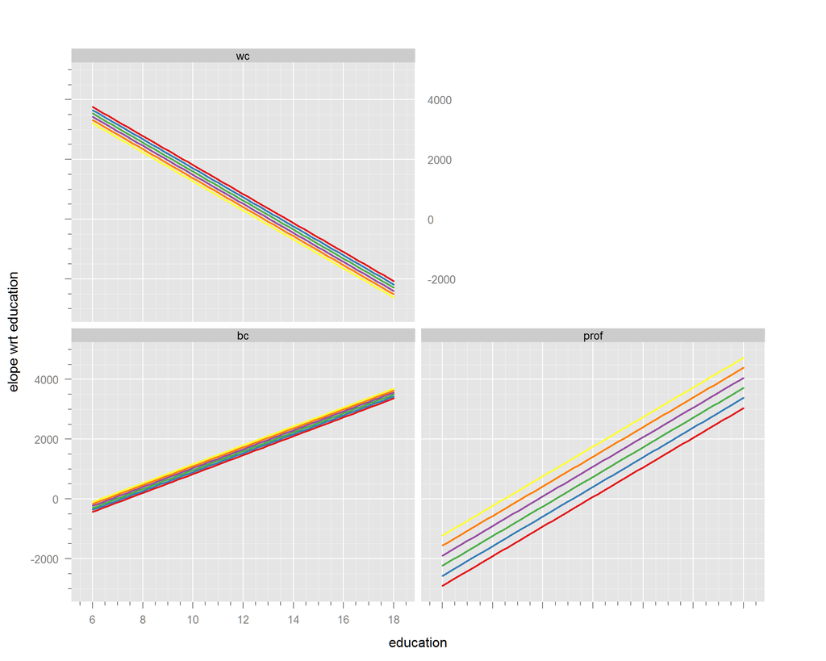

```r
xyplot( coef ~ education | type, ed.deriv, groups = women, type = 'l',
        ylab = 'elope wrt education')
```

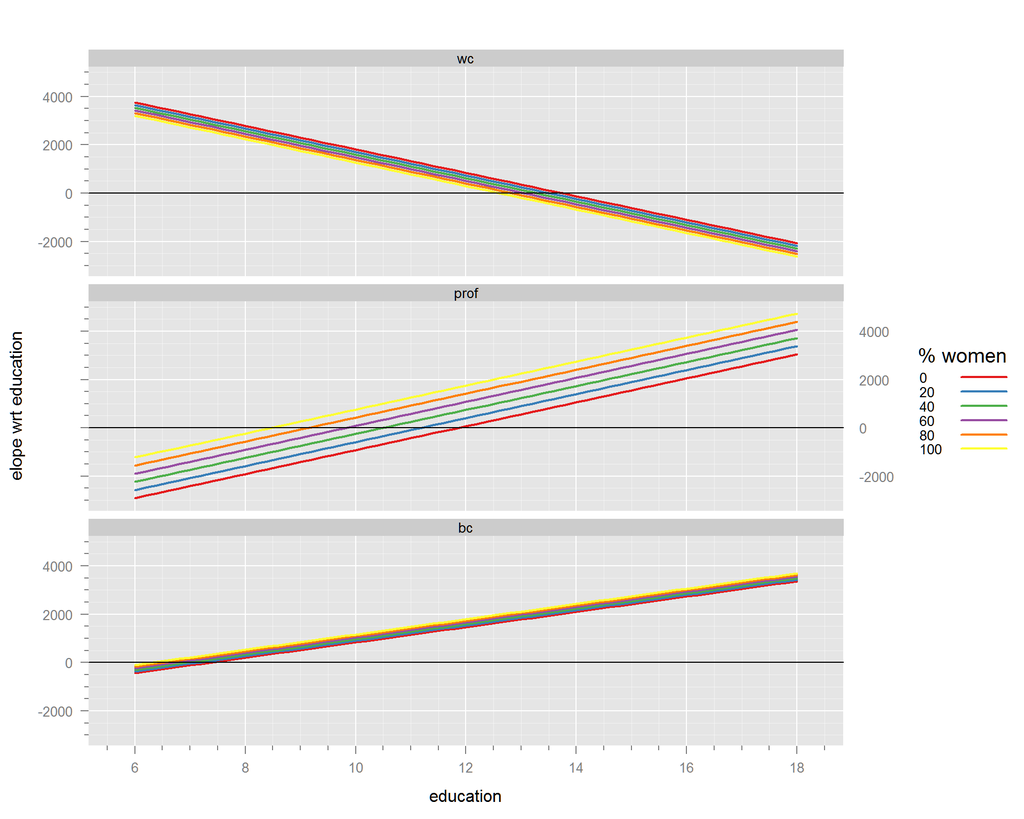

```r
xyplot( coef ~ education | type, ed.deriv, groups = women, type = 'l',
        ylab = 'elope wrt education',
        layout = c(1,3),
        auto.key = list(space = 'right',lines=T,points=F,title = "% women")) +
  layer(panel.abline(h=0))
```

Most of the individual coefficients answer questions that are of little interest because they are *marginal* to other terms. e.g. dropping a non-significant intercept just forces the model to go through the origin which, generally, would be a completely unjustified arbitrary restriction on the model

Dropping a main effect, e.g. ‘women’ that also appears in an interactionExample of ‘marginal’ terms that should **almost never** be dropped: 1. any term that is also included in a higher-order interaction 2. any term in a polynomial except the highest order term 3. the intercept which we can think of as being ‘included’ in all other terms

Are all quadratic terms jointly significant?

```r
wald(fit3q, "2")
```

```
     numDF denDF  F.value p.value
   2     6    79 3.653263 0.00298

   Coefficients                 Estimate  Std.Error DF   t-value p-value   Lower 0.95
     I(education^2)           158.202188 141.376157 79  1.119016 0.26652  -123.200013
     I(women^2)                 0.683644   0.226776 79  3.014625 0.00346     0.232258
     typeprof:I(education^2)   89.705722 410.272066 79  0.218649 0.82749  -726.920398
     typewc:I(education^2)   -401.078376 307.590803 79 -1.303935 0.19604 -1013.322555
     typeprof:I(women^2)        1.292266   1.096513 79  1.178522 0.24213    -0.890290
     typewc:I(women^2)         -0.060001   0.351274 79 -0.170809 0.86481    -0.759195

   Coefficients              Upper 0.95
     I(education^2)          439.604389
     I(women^2)                1.135029
     typeprof:I(education^2) 906.331841
     typewc:I(education^2)   211.165803
     typeprof:I(women^2)       3.474821
     typewc:I(women^2)         0.639193
```

Are all interaction terms jointly significant?

```r
wald(fit3q, ":")
```

```
     numDF denDF  F.value p.value
   :    11    79 1.827303 0.06299

   Coefficients                   Estimate    Std.Error DF   t-value p-value    Lower 0.95
     education:women              3.281036     5.333471 79  0.615178 0.54020     -7.334972
     typeprof:education       -3553.187956 10763.310916 79 -0.330120 0.74218 -24977.022432
     typewc:education          8999.157710  6189.470633 79  1.453946 0.14992  -3320.675411
     typeprof:women            -361.938860   387.190563 79 -0.934782 0.35275  -1132.622398
     typewc:women                52.466807   119.055431 79  0.440692 0.66064   -184.507100
     typeprof:I(education^2)     89.705722   410.272066 79  0.218649 0.82749   -726.920398
     typewc:I(education^2)     -401.078376   307.590803 79 -1.303935 0.19604  -1013.322555
     typeprof:I(women^2)          1.292266     1.096513 79  1.178522 0.24213     -0.890290
     typewc:I(women^2)           -0.060001     0.351274 79 -0.170809 0.86481     -0.759195
     typeprof:education:women    13.562716    23.329318 79  0.581359 0.56265    -32.873130
     typewc:education:women      -8.760494    11.969226 79 -0.731918 0.46638    -32.584642

   Coefficients                 Upper 0.95
     education:women             13.897045
     typeprof:education       17870.646520
     typewc:education         21318.990832
     typeprof:women             408.744678
     typewc:women               289.440715
     typeprof:I(education^2)    906.331841
     typewc:I(education^2)      211.165803
     typeprof:I(women^2)          3.474821
     typewc:I(women^2)            0.639193
     typeprof:education:women    59.998562
     typewc:education:women      15.063655
```

Are all 3-way and higher interaction terms jointly significant?

```r
wald(fit3q, ":.*:")
```

```
        numDF denDF   F.value p.value
   :.*:     2    79 0.4852239 0.61738

   Coefficients                Estimate Std.Error DF   t-value p-value Lower 0.95 Upper 0.95
     typeprof:education:women 13.562716  23.32932 79  0.581359 0.56265  -32.87313   59.99856
     typewc:education:women   -8.760494  11.96923 79 -0.731918 0.46638  -32.58464   15.06366
```

Are all terms involving education jointly significant?

```r
wald(fit3q, "education")
```

```
             numDF denDF  F.value p.value
   education     9    79 3.524747 0.00103

   Coefficients                   Estimate    Std.Error DF   t-value p-value    Lower 0.95
     education                -2327.853164  2403.830761 79 -0.968393 0.33580  -7112.558608
     I(education^2)             158.202188   141.376157 79  1.119016 0.26652   -123.200013
     education:women              3.281036     5.333471 79  0.615178 0.54020     -7.334972
     typeprof:education       -3553.187956 10763.310916 79 -0.330120 0.74218 -24977.022432
     typewc:education          8999.157710  6189.470633 79  1.453946 0.14992  -3320.675411
     typeprof:I(education^2)     89.705722   410.272066 79  0.218649 0.82749   -726.920398
     typewc:I(education^2)     -401.078376   307.590803 79 -1.303935 0.19604  -1013.322555
     typeprof:education:women    13.562716    23.329318 79  0.581359 0.56265    -32.873130
     typewc:education:women      -8.760494    11.969226 79 -0.731918 0.46638    -32.584642

   Coefficients                Upper 0.95
     education                 2456.85228
     I(education^2)             439.60439
     education:women             13.89705
     typeprof:education       17870.64652
     typewc:education         21318.99083
     typeprof:I(education^2)    906.33184
     typewc:I(education^2)      211.16580
     typeprof:education:women    59.99856
     typewc:education:women      15.06366
```

Are all terms involving women jointly significant?

```r
wald(fit3q, "women")
```

```
         numDF denDF  F.value p.value
   women     9    79 13.84135 <.00001

   Coefficients                  Estimate  Std.Error DF   t-value p-value   Lower 0.95
     women                    -120.734935  53.248201 79 -2.267399 0.02610  -226.722827
     I(women^2)                  0.683644   0.226776 79  3.014625 0.00346     0.232258
     education:women             3.281036   5.333471 79  0.615178 0.54020    -7.334972
     typeprof:women           -361.938860 387.190563 79 -0.934782 0.35275 -1132.622398
     typewc:women               52.466807 119.055431 79  0.440692 0.66064  -184.507100
     typeprof:I(women^2)         1.292266   1.096513 79  1.178522 0.24213    -0.890290
     typewc:I(women^2)          -0.060001   0.351274 79 -0.170809 0.86481    -0.759195
     typeprof:education:women   13.562716  23.329318 79  0.581359 0.56265   -32.873130
     typewc:education:women     -8.760494  11.969226 79 -0.731918 0.46638   -32.584642

   Coefficients               Upper 0.95
     women                    -14.747042
     I(women^2)                 1.135029
     education:women           13.897045
     typeprof:women           408.744678
     typewc:women             289.440715
     typeprof:I(women^2)        3.474821
     typewc:I(women^2)          0.639193
     typeprof:education:women  59.998562
     typewc:education:women    15.063655
```

Are all terms involving type jointly significant?

```r
wald(fit3q, "type")
```

```
        numDF denDF  F.value p.value
   type    12    79 1.014353 0.44416

   Coefficients                    Estimate    Std.Error DF   t-value p-value    Lower 0.95
     typeprof                  32541.822724 71720.983684 79  0.453728 0.65127 -1.102152e+05
     typewc                   -48907.797173 31439.995084 79 -1.555592 0.12380 -1.114875e+05
     typeprof:education        -3553.187956 10763.310916 79 -0.330120 0.74218 -2.497702e+04
     typewc:education           8999.157710  6189.470633 79  1.453946 0.14992 -3.320675e+03
     typeprof:women             -361.938860   387.190563 79 -0.934782 0.35275 -1.132622e+03
     typewc:women                 52.466807   119.055431 79  0.440692 0.66064 -1.845071e+02
     typeprof:I(education^2)      89.705722   410.272066 79  0.218649 0.82749 -7.269204e+02
     typewc:I(education^2)      -401.078376   307.590803 79 -1.303935 0.19604 -1.013323e+03
     typeprof:I(women^2)           1.292266     1.096513 79  1.178522 0.24213 -8.902900e-01
     typewc:I(women^2)            -0.060001     0.351274 79 -0.170809 0.86481 -7.591950e-01
     typeprof:education:women     13.562716    23.329318 79  0.581359 0.56265 -3.287313e+01
     typewc:education:women       -8.760494    11.969226 79 -0.731918 0.46638 -3.258464e+01

   Coefficients                 Upper 0.95
     typeprof                 1.752989e+05
     typewc                   1.367195e+04
     typeprof:education       1.787065e+04
     typewc:education         2.131899e+04
     typeprof:women           4.087447e+02
     typewc:women             2.894407e+02
     typeprof:I(education^2)  9.063318e+02
     typewc:I(education^2)    2.111658e+02
     typeprof:I(women^2)      3.474821e+00
     typewc:I(women^2)        6.391930e-01
     typeprof:education:women 5.999856e+01
     typewc:education:women   1.506366e+01
```

Some questions: Using this model:

1. What does the coefficient for ‘women’ mean?
2. What does the coefficient for ‘women^2’ mean?
3. How would you estimate the increase in income associated with an extra year of education in a white collar occupation that is 40% female?
4. How would you estimate the increase in income associated with an extra year of education for a professional occupation that is 20% female?

### Showing predicted income with graphs

How much of an increase in income is associated with an additional year of education? Note that I found it hard to say: ’how much does income go up when you have an extra year of education? in order to avoid the causal implications. This is quite hard and feels unnatural.

This is a sequence of graphs showing how predicted income, using the model fitted above, varies by gender composition and type of occupation.

Since we’re using 2-D graphs, we can only show the dependent variable, income, as a continuous variable and one more continuous variable for the x-axis. But we have two continuous predictors. Let’s choose education for the x-axis, which leaves the problem of what to do with the percentage of women.  
We need to choose a number of representative levels for percentage to use as an ordinal categorical variable.

There are a number of approaches to show predicted values for a model. I’ll illustrate two of them. One way generated a data frame with crossed combinations of the predictor variable values and plot the resulting predicted values. A second way uses a data frame whose values for predictor variables reflects the interdependencies in the data. We’ll see both. We’ll start with the second method.

We’ll use the data but we can’t use the raw values of the ‘% women’ because we want to use just a few typical levels of that variable. One approach is to round the values into an appropriate number of categories.

```r
pred <- subset(Prestige, !is.na(type)) # drop occupations where type is NA
# discretize gender
(20 * round(pred$women/20)) %>% unique
```

```
   [1]  20   0  60  40  80 100
```

```r
(20 * round(pred$women/20)) %>% tab
```

```
       0    20    40    60    80   100 Total
      41    21    10     9    10     7    98
```

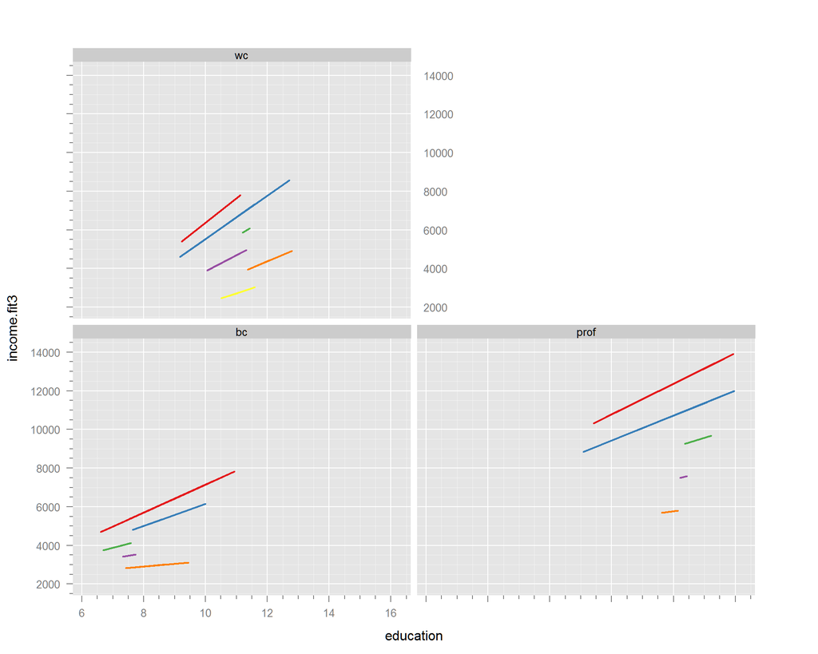

```r
pred$women.orig <- pred$women  # save original value because we're about to overwrite them
pred$women <- 20 * round(pred$women/20)  # we need to overwrite to use the 'predict' function
pred$income.fit3 <- predict(fit3, newdata = pred) # predicted income using model fit3

xyplot( income.fit3 ~ education | type, pred,
        groups = women, type = 'l')
```

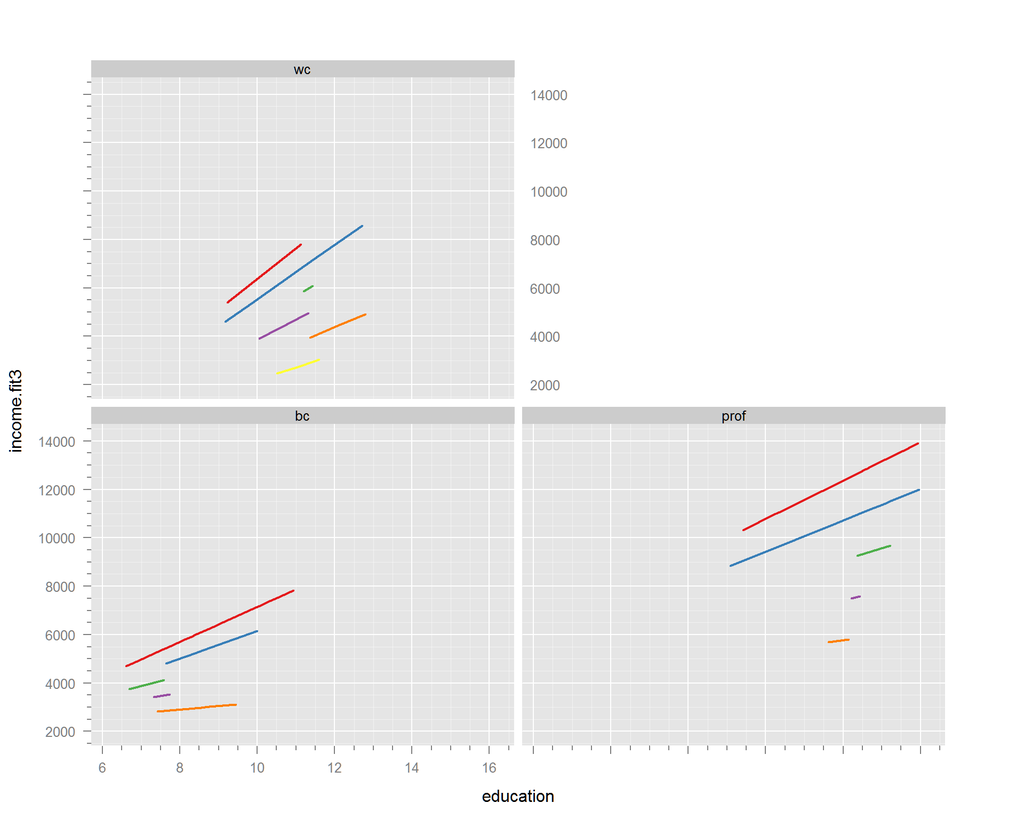

```r
pred <- sortdf(pred, ~ education)
xyplot( income.fit3 ~ education | type, pred,
        groups = women, type = 'l')
```

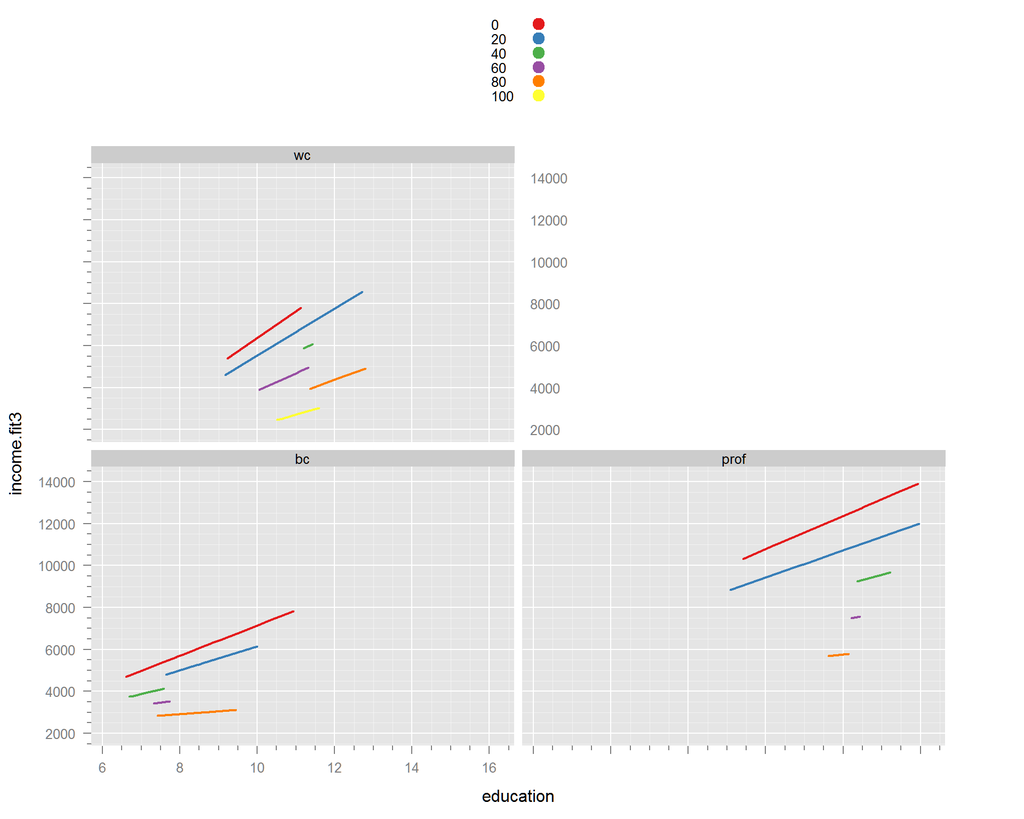

```r
gd(7, lwd = 2, lty = 1)
xyplot( income.fit3 ~ education | type, pred,
        groups = women, type = 'l',
        auto.key = T)
```

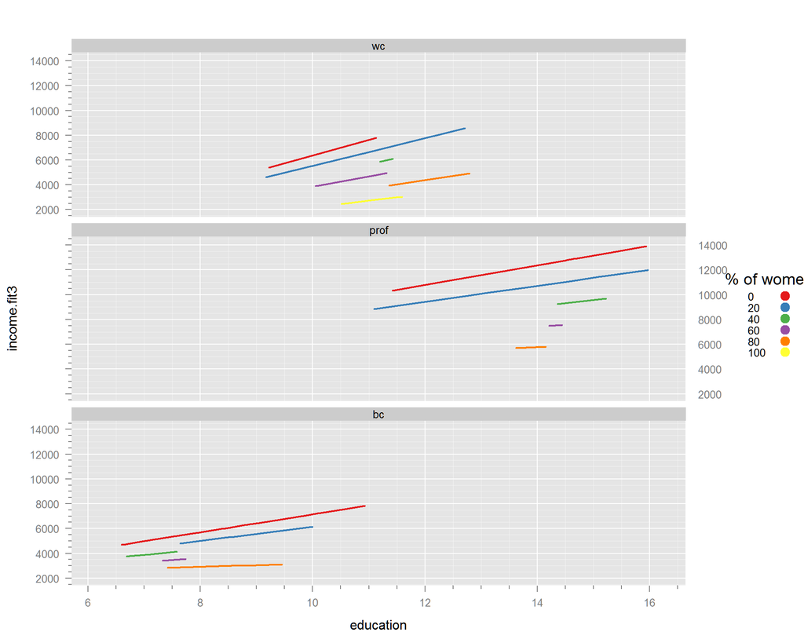

```r
xyplot( income.fit3 ~ education | type, pred,
        groups = women, type = 'l',
        layout = c(1,3),
        auto.key =
          list( space='right', title='% of women'))
```

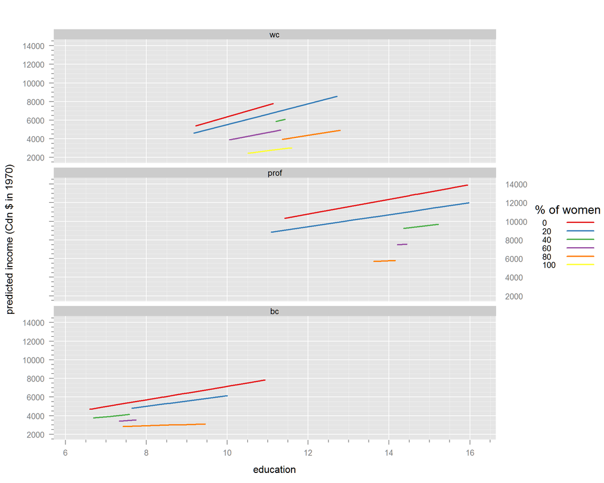

```r
xyplot( income.fit3 ~ education | type, pred,
        groups = women, type = 'l',
        ylab = 'predicted income (Cdn $ in 1970)',
        layout = c(1,3),
        auto.key =
          list( space='right', title='% of women',
                points = FALSE, lines = TRUE))
```

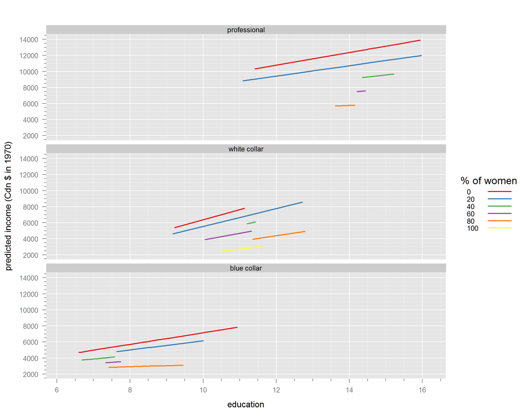

```r
pred$Type <- tr(pred$type, levels(pred$type),
            c("blue collar",'professional','white collar'))

pred$Type <- reorder(pred$Type, pred$education)
xyplot( income.fit3 ~ education | Type, pred,
        groups = women, type = 'l',
        ylab = 'predicted income (Cdn $ in 1970)',
        layout = c(1,3),
        auto.key = list( space='right', title='% of women',
                         points = FALSE, lines = TRUE),
        scales = list(y=list(alternating=F)))
```

Switching panel and grouping variables

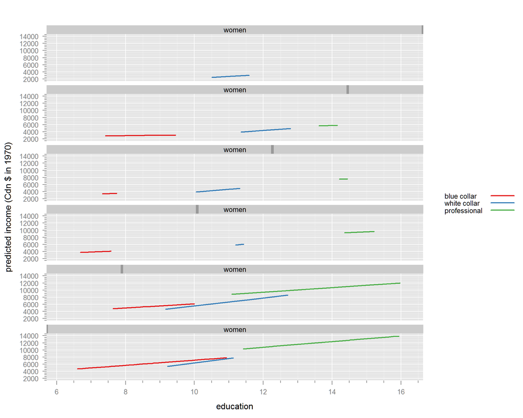

```r
xyplot( income.fit3 ~ education | women, pred, groups = Type,
        type = 'l',
        ylab = 'predicted income (Cdn $ in 1970)',
        layout = c(1,6),
        auto.key = list( space='right',
                         points = FALSE, lines = TRUE),
        scales = list(y=list(alternating=F)))
```

Note the gray bar in the strips that shows the level of ‘women’ in each panel. It’s okay for exploration, but a lay viewer won’t know what it means.

Also the colours are “strooped” (look up “Stroop effect”).

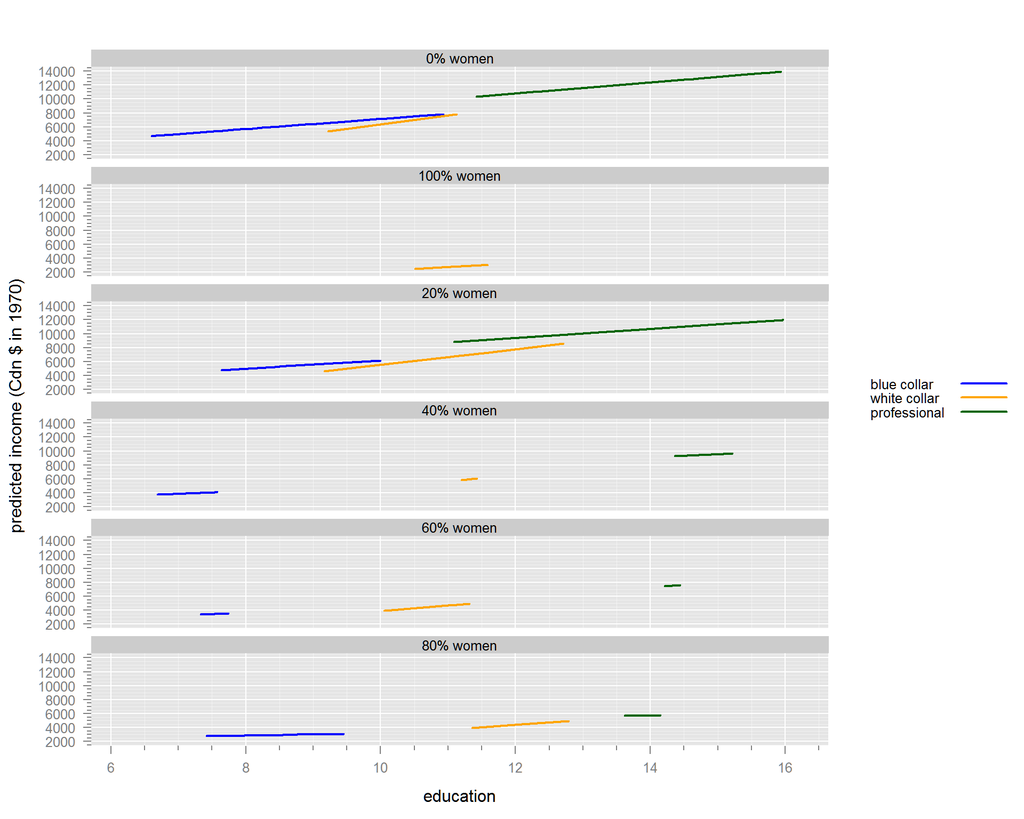

```r
pred$Women <- with(pred, paste0(women, "% women"))
gd(col = c('blue','orange','dark green'), lty = 1, lwd = 2)
xyplot( income.fit3 ~ education | Women, pred, groups = Type,
        type = 'l',
        ylab = 'predicted income (Cdn $ in 1970)',
        layout = c(1,6),
        auto.key = list( space='right',
                         points = FALSE, lines = TRUE),
        scales = list(y=list(alternating=F)),
        as.table = TRUE)
```

Ooops! The % labels are in *lexicographical order*. We want them in order corresponding to the numerical value of the percentage.

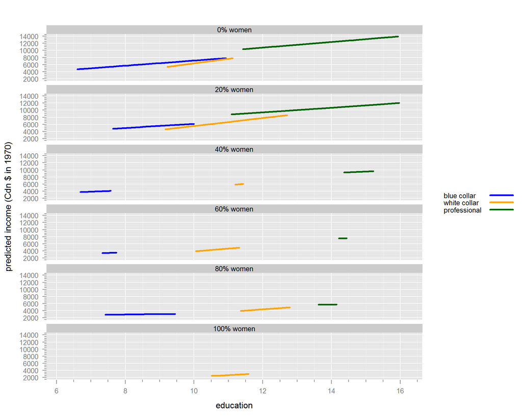

```r
pred$Women <- with(pred, reorder(Women, women))
      # reorders the levels of 'Women' according to the mean of 'women'
gd(col = c('blue','orange','dark green'), lty = 1, lwd = 3)
xyplot( income.fit3 ~ education | Women, pred, groups = Type,
        type = 'l',
        ylab = 'predicted income (Cdn $ in 1970)',
        layout = c(1,6),
        auto.key = list( space='right',
                         points = FALSE, lines = TRUE),
        scales = list(y=list(alternating=F)),
        as.table = TRUE)
```

This presentation is not very effective because it is difficult to compare levels vertically. But we have too many levels to show them side by side vertically.

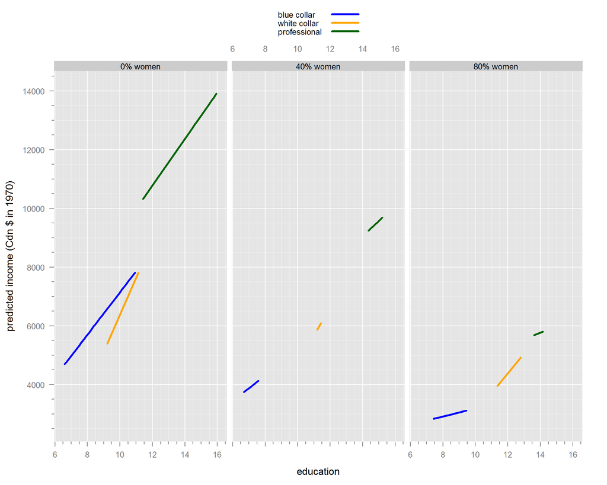

```r
xyplot( income.fit3 ~ education | Women,
        subset(pred, Women %in% c("0% women",'40% women','80% women')),
        groups = Type,
        type = 'l',
        ylab = 'predicted income (Cdn $ in 1970)',
        layout = c(3,1),
        auto.key = list( space='top',
                         points = FALSE, lines = TRUE),
        scales = list(y=list(alternating=F)),
        as.table = TRUE)
```

# What is the ‘value’ of an additional year of education?

## Using GLH and graphs to probe complex questions (INCOMPLETE)

Using GLH we will be able to, among other things:

1. put confidence bounds around the predicted values above
2. estimated the magnitude and significance of differences between types for various combinations of gender composition and education
3. estimate association between education and income for various combinations of gender and type

# Some R Markdown examples (This is a level 1 heading)

Note that headings are created with ‘number signs’ and the level of the heading is indicated with the number of ‘number signs’

## This is a subheading

This is a bullet list:

- item number 1
- item number 2

and this is a numbered list:

1. first time
2. second item (it doesn’t matter what number you use in the source code.

This is an example of a link that happens to show you where to get help on R Markdown:

1. [R Markdown Cheat Sheet](https://www.rstudio.com/wp-content/uploads/2015/02/rmarkdown-cheatsheet.pdf)
2. [More documentation](http://rmarkdown.rstudio.com/)

You can also use LaTeX to generate equations:

$$f(x|\mu) = \frac{1}{\sqrt{2 \pi}}e^{-(x-\mu)^2/2}$$

You can also insert R output in a text paragraph: e.g. 2 + 3 = 5. Did we get that right?